| Hazırlayan / Author | Versiyon / Version | Tarih / Date | Dil / Lang. |
| --- | --- | --- | --- |
| dataFLOYD | v1.01 | 23 Ağu 2018 | TR |

# Python "matplotlib" kütüphanesini kullanarak veri görselleştirme - Temel Grafikler

Görselleştirme elimizdeki veriyi anlamanın en iyi yoludur. Python matplotlib kütüphanesini kullanarak veri seti üzerinde istediğimiz görselleştirmeleri gerçekleştirebiliriz

İşe matplotlib kütüphanesini yükleyerek başlayacağız ve aşamalı bir yaklaşımla ilerleyeceğiz. Yani grafikleri en sade hallerinden çizdirmeye başlayacak ve üzerine eklemeler yapacağız.

```python
# matplotlib kütüphanesi çağrılıyor
import matplotlib.pyplot as plt

fig_size = [16,9]

# Nümerik numpy kütüphanesini de ekleyelim ne olur ne olmaz :)
import numpy as np
```

**ÇİZGİ GRAFİKLERİ (LINE GRAPH)**

Bu tip grafikler en basit grafik tipi olup iki değişken arasındaki bağlantıyı görselleştirmemize yaramaktadır. Çizgi grafikler adından anlaşılabileceği gibi birbirini takip eden veriler arasına çizgi oluşturulmasını sağlar. Bunu gösterebilmek için basit bir fonksiyon kullanalım

En basit haliyle bir "sinüs" verisi yaratalım ve grafiğini çizdirelim. İlerleyen adımlarda bu grafiğin üzerinde değişiklikler yaparak grafiği geliştirelim.

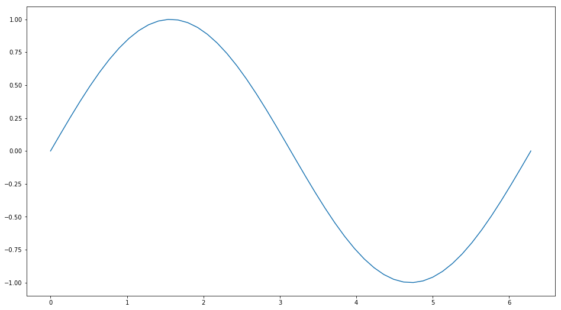

```python
# 0'dan 2*pi'ye
x = np.linspace(0,np.pi*2,50)
y = np.sin(x)

plt.figure(figsize=fig_size)
plt.plot(x,y)

plt.show();
```

Gördüğünüz gibi bu grafik bile çok şey anlatmakta fakat bunu biraz daha geliştirelim hep beraber. Adım adım ilerliyelim:

- Grafiğe eksen isimlerini ve başlığı ekleyelim.
- Aynı zamanda ızgara da (grid) ekleyelim.  
  *Not*: Diğer grafik türleri için de hemen hemen aynı fonksiyonlar kullanılabilmekte.

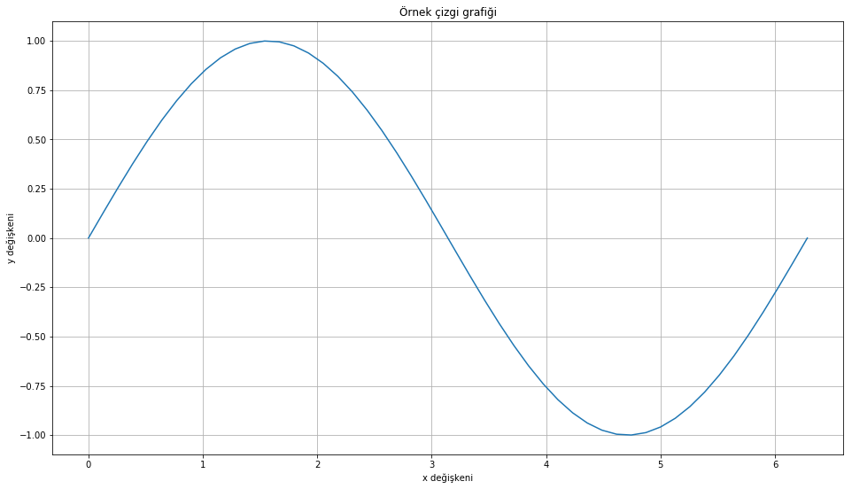

```python
plt.figure(figsize=fig_size)
plt.plot(x,y)

# y eksenine isim ekliyoruz
plt.ylabel("y değişkeni")
# x eksenine isim ekliyoruz
plt.xlabel("x değişkeni")
# grafiğe başlık ekliyoruz
plt.title("Örnek çizgi grafiği");
# ızgara ekliyoruz
plt.grid()

plt.show();
```

- Grafiğimizi daha anlaşılır hale getirmek için veri noktalarını da belirginleştirelim.
- Rengi kırmızı olan ikinci bir çizgi grafiği ekleyelim. Çizginin kalınlığı 5 olsun
- Ayrıca bir de lejand (legend) ekleyim

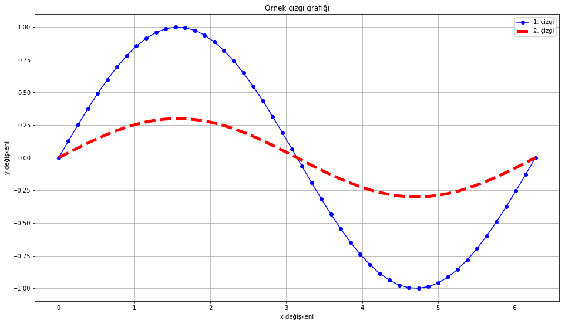

```python
plt.figure(figsize=fig_size)

# Veri noktalarını belirginleştiriyoruz.
plt.plot(x,y,'-ob')
# İkinci bir grafik ekleyelim. Kesik çizgili ve kırmızı olsun
plt.plot(x,y*0.3,'--r',linewidth=5)


# y eksenine isim ekliyoruz
plt.ylabel("y değişkeni")
# x eksenine isim ekliyoruz
plt.xlabel("x değişkeni")
# grafiğe başlık ekliyoruz
plt.title("Örnek çizgi grafiği")
# ızgara ekliyoruz
plt.grid()
# lejand ekliyoruz
plt.legend(["1. çizgi","2. çizgi"])

plt.show();
```

- x eksenin çizgilerini 0, pi/2, pi, 3pi/2, 2pi olacak şekilde ayarlayalım ve bunların isimlerini x ekseni üzerinde gösterelim.
- Ayrıca grafiğin üzerinde pi değerine bir annotasyon koyalım.

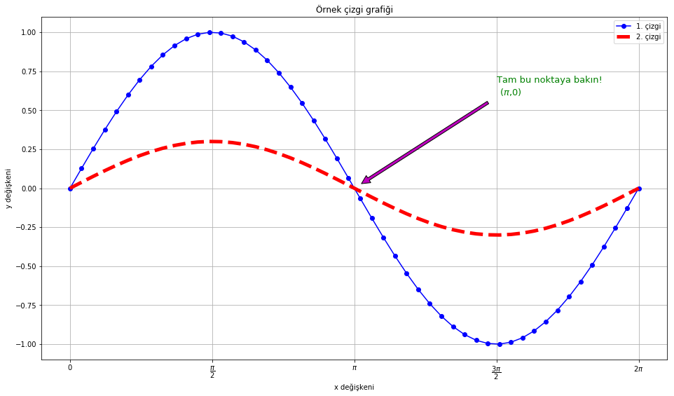

```python
plt.figure(figsize=fig_size)

# Veri noktalarını belirginleştiriyoruz.
plt.plot(x,y,'-ob')
# İkinci bir grafik ekleyelim. Kesik çizgili ve kırmızı olsun
plt.plot(x,y*0.3,'--r',linewidth=5)


# y eksenine isim ekliyoruz
plt.ylabel("y değişkeni")
# x eksenine isim ekliyoruz
plt.xlabel("x değişkeni")
# grafiğe başlık ekliyoruz
plt.title("Örnek çizgi grafiği")
# ızgara ekliyoruz
plt.grid()
# lejand ekliyoruz
plt.legend(["1. çizgi","2. çizgi"])
# Lokasyonları istediğimiz değerlere ayarlayalım. Bu değerlerin yazı kısmını ise biraz Latex kullanarak yazabiliriz.
plt.xticks([0,np.pi/2,np.pi,1.5*np.pi,2*np.pi],[r"0",r"$\dfrac{\pi}{2}$","$\pi$",r"$\dfrac{3\pi}{2}$","$2\pi$"])

plt.annotate("Tam bu noktaya bakın!\n ($\pi$,0)",[np.pi,0],[1.5*np.pi,0.6],
             arrowprops=dict(facecolor='m', shrink=0.05,),fontsize=13,color="g")

plt.show();
```

Çizgi grafikle daha çok şey yapılabilir, şimdi ilerlemek adına bir sonraki grafik türüne geçiyoruz.

**DAĞILIM GRAFİĞİ (SCATTER GRAPH)**

Bu grafikler genelde iki değişkenin aralarındaki ilişkiyi gözönüne sermek için kullanılır. Üç boyutlu versiyonları da vardır, onlara da ilerleyen bölümlerde inceleriz. Bu amaçla çok meşhur iris verisetini kullanalım.

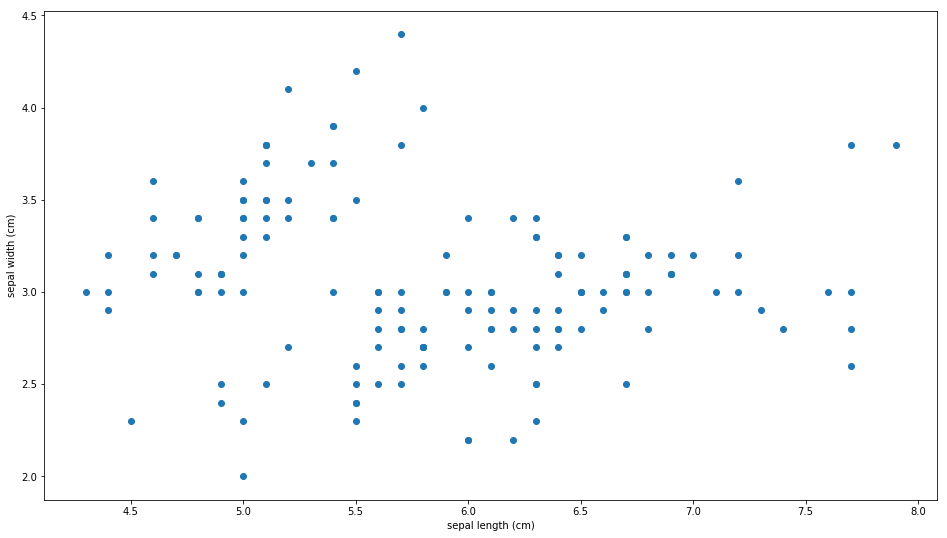

```python
#veri setleri yükleniyor
from sklearn.datasets import load_iris

iris = load_iris()

# Yeni figür oluşturuluyor
plt.figure(figsize=fig_size)
# ilk ve ikinci öznitelik için scatter grafiğini çizdirelim
plt.scatter(iris.data[:,0],iris.data[:,1])
# x ve y eksenine isimleri de yazalım
plt.xlabel(iris.feature_names[0])
plt.ylabel(iris.feature_names[1])

plt.show();
```

- Hazırladığımız grafiği iris veri setindeki sınıflar uyarınca renklendirelim.
- Ek olarak boyutları 3. özniteliğe göre değiştirelim

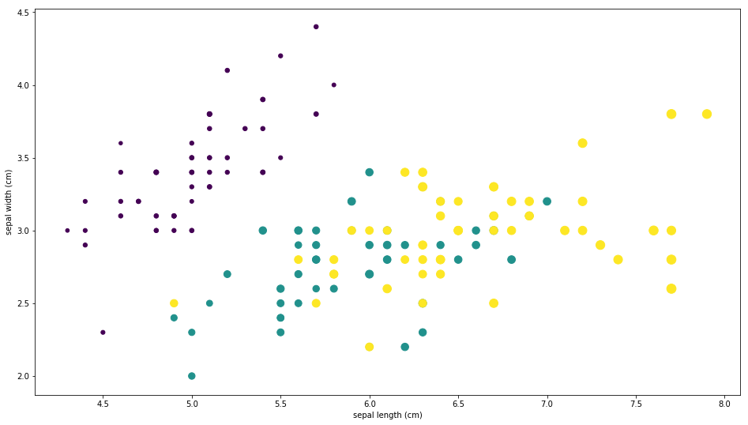

```python
# Yeni figür oluşturuluyor
plt.figure(figsize=fig_size)
# ilk ve ikinci öznitelik için scatter grafiğini çizdirelim
plt.scatter(iris.data[:,0],iris.data[:,1],c=iris.target,s=iris.data[:,2]*20)
# x ve y eksenine isimleri de yazalım
plt.xlabel(iris.feature_names[0])
plt.ylabel(iris.feature_names[1])

plt.show();
```

Yukarıdaki grafikte hangi rengin hangi sınıfa ait olduğu belli olmuyor. Bunun için bir "legend" eklememiz gerekiyor. Öncelikle veri setinde kaç sınıf olduğuna bakalım:

```python
iris.target_names
```

```
array(['setosa', 'versicolor', 'virginica'], dtype='<U10')
```

Gördüğünüz gibi 3 sınıf var. İlk sınıfı kırmızı, ikinci sınıfı mavi, üçüncü sınıfı yeşil çizdirelim. Bunun için bir for döngüsü kullanırsak iyi olacak. Böylelikle "legend"ı renklere göre atayabiliriz.

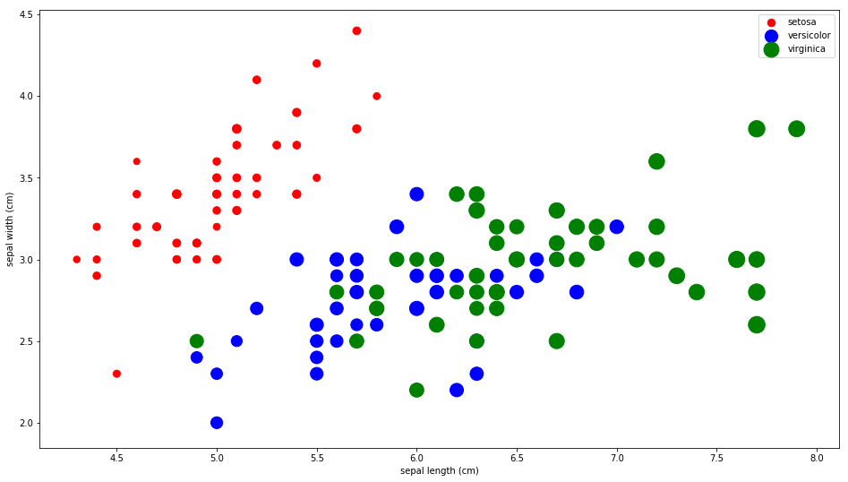

```python
;# Renk isimlerini belirliyoruz
colors = ["r","b","g"]
# figure oluşturalım
plt.figure(figsize=fig_size)

# x ve y eksenine isimleri de yazalım
plt.xlabel(iris.feature_names[0])
plt.ylabel(iris.feature_names[1])

# for döndürelim
# burada enumerate kalıbı i değişkenini almamıza yarıyor
for i,name in enumerate(iris.target_names):
    plt.scatter(iris.data[iris.target==i,0],iris.data[iris.target==i,1],s=iris.data[iris.target==i,2]*50,c=colors[i])
plt.legend(iris.target_names)

plt.show()
```

Grafik fena değil ama "legend kısmındaki boyutların homojen olmasını istersek ne yapacağız" dediğinizi duyar gibiyim. Biraz daha kod üstünde oynayalım. Ve son bonus olarak şekilleri de çok ilginç şeyler yapalım :) Bunun için standart denklem formatını kullanacağız.

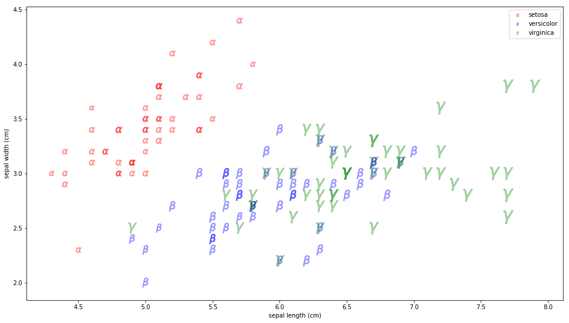

```python
# Renk isimlerini belirliyoruz
colors = ["r","b","g"]
# şekiller standart denklem formatında
shapes = [r'$\alpha$',r'$\beta$',r'$\gamma$']
# figure oluşturalım
plt.figure(figsize=fig_size)


# x ve y eksenine isimleri de yazalım
plt.xlabel(iris.feature_names[0])
plt.ylabel(iris.feature_names[1])

# for döndürelim
# burada enumerate kalıbı i değişkenini almamıza yarıyor
for i,name in enumerate(iris.target_names):
    plt.scatter(iris.data[iris.target==i,0],iris.data[iris.target==i,1],s=iris.data[iris.target==i,2]*70,
                c=colors[i],
                marker=shapes[i],
               alpha=0.3)
lgnd = plt.legend(iris.target_names)

#Her üç eleman için de boyutu sabitleyelim
lgnd.legendHandles[0]._sizes = [30]
lgnd.legendHandles[1]._sizes = [30]
lgnd.legendHandles[2]._sizes = [30]
```

Sanırım dağılım grafiği için temel fikri anladınız. Şimdi başka bir grafik tipine geçebiliriz.

**SÜTUN GRAFİK (BAR PLOT)**

Adı üstünde sütun grafik işte diyip geçmeyin :) Bakalım burada neler yapacağız...

İşe basit bir veri oluşturmakla başlayalım.

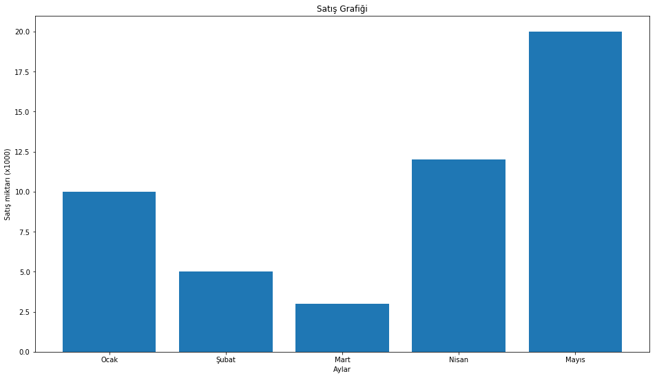

```python
plt.figure(figsize=fig_size)
y = [10,5,3,12,20]
x_labels = ['Ocak','Şubat','Mart','Nisan','Mayıs']
x_pos = np.arange(len(y))

plt.bar(x_pos,y)

plt.title("Satış Grafiği")

plt.xticks(x_pos,x_labels);

plt.xlabel("Aylar")
plt.ylabel("Satış miktarı (x1000)")
plt.show();
```

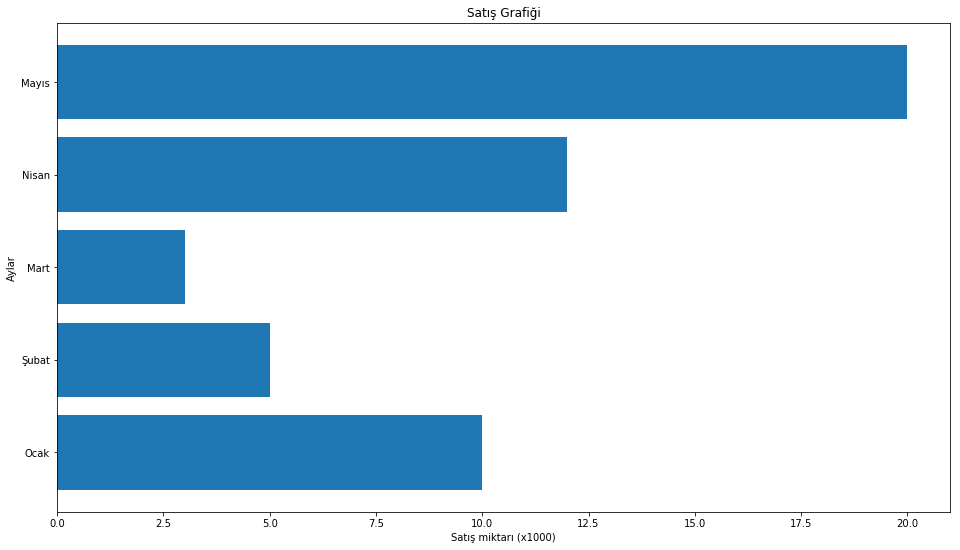

```python
plt.figure(figsize=fig_size)
y = [10,5,3,12,20]
x_labels = ['Ocak','Şubat','Mart','Nisan','Mayıs']
x_pos = np.arange(len(y))

plt.barh(x_pos,y)

plt.title("Satış Grafiği")

plt.yticks(x_pos,x_labels);

plt.ylabel("Aylar")
plt.xlabel("Satış miktarı (x1000)")
plt.show();
```

- Her bir sütunu farklı renkte yapalım
- Sütunların kenarları değişik renklerde ve görünebilir bir kalınlıkta olsun
- Sütunların genişliklerini de değiştirelim

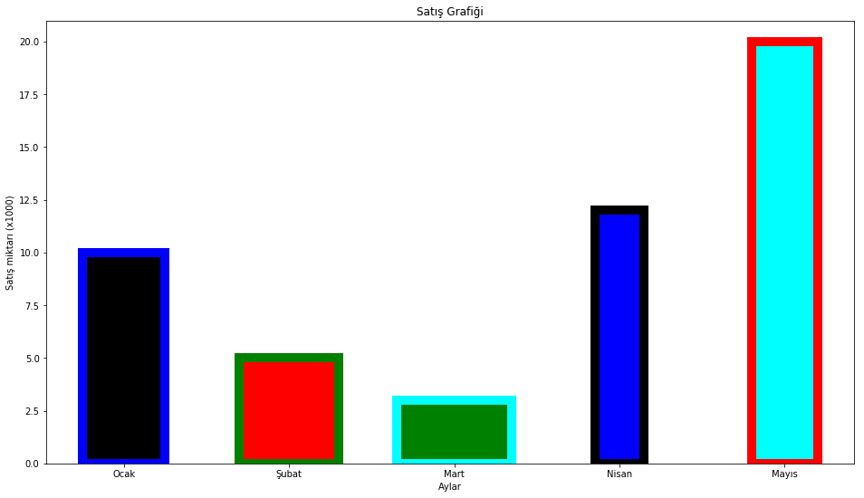

```python
plt.figure(figsize=fig_size)
y = [10,5,3,12,20]
x_labels = ['Ocak','Şubat','Mart','Nisan','Mayıs']
x_pos = np.arange(len(y))

plt.bar(x_pos,y,color=['black', 'red', 'green', 'blue', 'cyan'],
        edgecolor=["blue","green","cyan","black","red"],
       linewidth = 10,
       width = [0.5,0.6,0.7,0.3,0.4])

plt.title("Satış Grafiği")

plt.xticks(x_pos,x_labels);

plt.xlabel("Aylar")
plt.ylabel("Satış miktarı (x1000)")
plt.show();
```

**YIĞIN SÜTUN GRAFİK / GRUP SÜTUN GRAFİK (STACKED/GROUPED BAR PLOT)**

Sütun grafikleri üst üste veya yan yana koyarak da görselleştirme yapılabilir. İlk önce grup sütun grafiğe bakalım. Bu grafiği doğrudan çizdirebilen başkan kütüphaneler mevcut. Biz burada tüm parametreleri el ile ayarlayarak, pyplot imkanları ile çizdirmeye çalışalım.

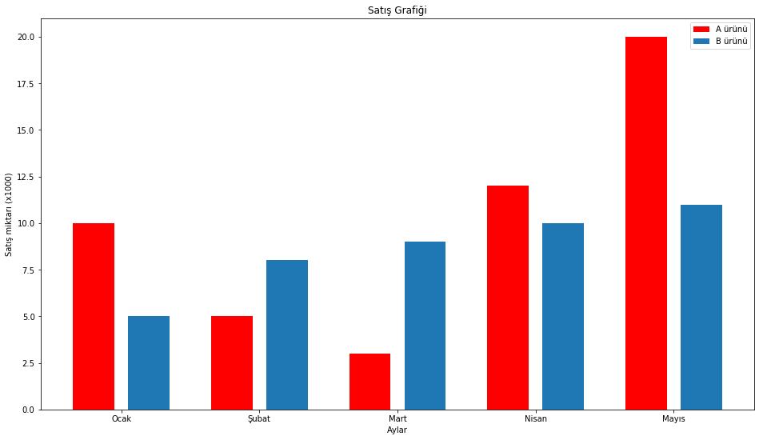

```python
plt.figure(figsize=fig_size)
y_1 = [10,5,3,12,20]
y_2 = [5,8,9,10,11]
x_labels = ['Ocak','Şubat','Mart','Nisan','Mayıs']
x_pos = np.arange(len(y))

plt.bar(x_pos-0.2,y_1,color="r",width=0.3)
plt.bar(x_pos+0.2,y_2,width=0.3)


plt.title("Satış Grafiği")

plt.xticks(x_pos,x_labels);

plt.xlabel("Aylar")
plt.ylabel("Satış miktarı (x1000)")

plt.legend(["A ürünü","B ürünü"])
plt.show();
```

Yığın halinde sütun çizdirmek istersek "bottom" parametresini bir önceki seri olarak verebiliriz.

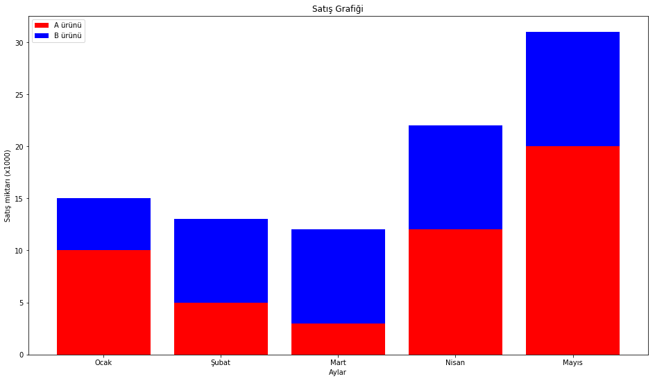

```python
plt.figure(figsize=fig_size)
y_1 = [10,5,3,12,20]
y_2 = [5,8,9,10,11]
x_labels = ['Ocak','Şubat','Mart','Nisan','Mayıs']
x_pos = np.arange(len(y))

plt.bar(x_pos,y_1,color="r")
plt.bar(x_pos,y_2,color="b",bottom=y_1)


plt.title("Satış Grafiği")

plt.xticks(x_pos,x_labels);

plt.xlabel("Aylar")
plt.ylabel("Satış miktarı (x1000)")

plt.legend(["A ürünü","B ürünü"])
plt.show();
```

**HISTOGRAM GRAFİĞİ**

Sütun grafiğin özelleşmiş bir hali olan histogram bir değişkenin dağılımını göstermek için kullanılır.

Histogram için normal dağılımı rastgele bir veri yaratalım ve bunu çizdirelim.

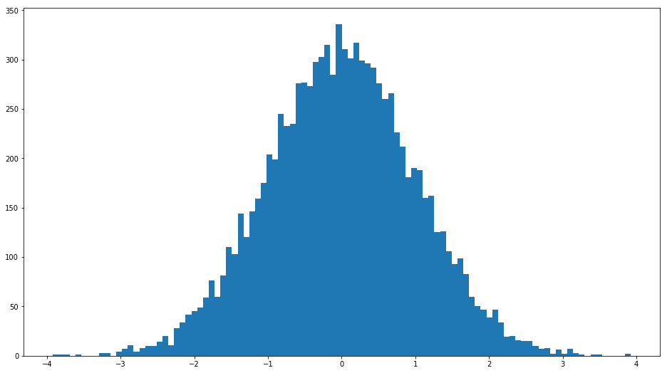

```python
number_of_samples = 10000

np.random.seed(42)

y = np.random.randn(number_of_samples)

plt.figure(figsize=fig_size)

plt.hist(y,bins=100);
```

**"BOXPLOT" GRAFİĞİ**

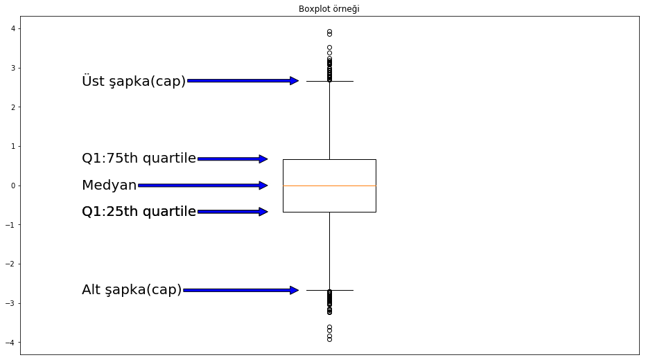

```python
number_of_samples = 10000

np.random.seed(42)

y = np.random.randn(number_of_samples)

plt.figure(figsize=fig_size)

ret = plt.boxplot(y);

#---------------------------
# Annotations
median = [item.get_ydata()[0] for item in ret['medians']]
plt.annotate("Medyan",[0.9,median[0]],[0.6,median[0]],va='center',
         arrowprops=dict(facecolor='b'),fontsize=20,color="k")

boxes = [item.get_ydata() for item in ret['boxes']]
plt.annotate("Q1:25th quartile",[0.9,boxes[0][0]],[0.6,boxes[0][0]],va='center',
         arrowprops=dict(facecolor='b'),fontsize=20,color="k")
plt.annotate("Q1:25th quartile",[0.9,boxes[0][0]],[0.6,boxes[0][0]],va='center',
         arrowprops=dict(facecolor='b'),fontsize=20,color="k")
plt.annotate("Q1:75th quartile",[0.9,boxes[0][2]],[0.6,boxes[0][2]],va='center',
         arrowprops=dict(facecolor='b'),fontsize=20,color="k")

caps = [item.get_ydata() for item in ret['caps']]
plt.annotate("Alt şapka(cap)",[0.95,caps[0][0]],[0.6,caps[0][0]],va='center',
         arrowprops=dict(facecolor='b'),fontsize=20,color="k")
plt.annotate("Üst şapka(cap)",[0.95,caps[1][0]],[0.6,caps[1][0]],va='center',
         arrowprops=dict(facecolor='b'),fontsize=20,color="k")
#---------------------------

plt.title("Boxplot örneği")
plt.xticks([],[])
plt.show();
```